# STV2022 – Store tekstdata

Solveig Bjørkholt og Martin Søyland

2022-07-13

# 1 Introduksjon

Velkommen til STV2022 – Store teksdata!

Dette er en arbeidsbok som går gjennom de forskjellige delene i kurset, med tilhørende R-kode. Meningen med arbeidsboken, er at den kan brukes som forslag til implementering av metoder i semesteroppgaven. Merk likevel at dette ikke er en fasit!

## 1.1 Kort om kurset

I kurset skal vi bli kjent med analyseprosessen av store tekstdata: Hvordan samler man effektivt og redelig store mengder politiske tekster? Hva må til for å gjøre slike tekster klare for analyse? Og hvordan kan vi analysere tekstene?

Politikere og politiske partier produserer store mengder tekst hver dag. Om det er gjennom debatter, taler på Stortinget, lovforslag fra regjeringen, høringer, offentlige utredninger med mer, er digitaliserte politiske tekster i det offentlige blitt mer tilgjengelig de siste tiårene. Dette har åpnet et mulighetsrom for tekstanalyse som ikke var mulig/veldig vanskelig og tidkrevende før.

Det kan ofte være vanskelig å finne mønster som kan svare på spørsmål og teorier vi har i statsvitenskap i disse store tekstsamlingene. Derfor kan vi se til metoder innenfor maskinlæring for å analysere store samlinger av tekst systematisk. Samtidig er ikke alltid digitaliserte politiske tekster tilrettelagt for å analysers direkte. I disse tilfellene er god strukturering av rådata viktig.

Gjennom å delta i dette kurset vil du lære å søke i store mengder dokumenter, oppsummere disse på meningsfulle måter og indentifisere riktige analysemetoder for å teste statsvitenskaplige teorier med store tekstdata. Kurset vil dekke samling av store volum tekst fra offentlige kilder, strukturering og klargjøring av tekst for analyse og kvantitative tekstanalysemetoder.

## 1.2 Oppbygging av arbeidsboken

Denne arbeidsboken er ment som supplement til pensum i kurset forøvrig. Her vil vi gå gjennom de ulike delene av kurset, og spesielt legge oss tett opp til seminarundervisningen.

Under vil vi gå gjennom undervisningsopplegget, som arbeidsboken er lagt opp etter. Delene av boken er strukturert som følgende:

1. Anskaffelse av tekst
2. Laste inn eksisterende tekstkilder
3. Forbehandling av tekst (preprosessering)
4. Veiledet læring (supervised)
5. Ikke-veiledet læring (unsupervised)
6. Ordbøker
7. Tekstsatistikk
8. Sentiment
9. Temamodellering
10. Latente posisjoner i tekst

### 1.2.1 Nødvendige pakker

Vi kommer til å bruke noen pakker gjennom kurset, som det kan være lurt å lære seg litt ekstra godt. Disse pakkene er:

| Pakkenavn | Beskrivelse |
| --- | --- |
| tidyverse | Inneholder pakker som `dplyr`, `ggplot2`, `stringr`, med mer. For data wrangling |
| tidytext | Grunnpakke for preprosessering av data |
| stortingscrape | Enkel måte å skrape data fra Stortinget på (flittig brukt som dataeksempel) |
| stm | For å kjøre strukturelle temamodeller |
| NorSentLex | Sentimentordbøker på norsk |
| haven | For å laste inn forskjellige dataformater (SPSS, Stata og SAS) |
| … |  |

## 1.3 Anbefalte forberedelser

Siden kurset krever noe forkunnskap om R og generell metodisk kompetanse, anbefaler vi å se over følgende materiale før kurset starter:

- [Arbeidsbøker for R ved UiO](https://shinyibv02.uio.no/connect/#/apps/55/access)
- [R materiale for STV1020](https://github.com/liserodland/STV1020)

# 2 Undervisning

Undervisningen i STV2022 består av 10 forelesninger og 5 seminarer. Vi vil bruke forelesningene til å oppsummere hovedkonseptene i hver ukes tema, både metodisk og anvendt. Seminarene vil ha hovedfokus på teknisk gjennomføring av tekstanalyse i R. Hvert seminar vil være delt i to med én del der seminarleder går gjennom ekstempler på kodeimplementering og én del der studentene kan jobbe med semesteroppgaven. Det er også verdt å merke seg at mange av implementeringene i kurset krever en del prøving og feiling.

Merk at det etter hvert seminar skal leveres inn et utkast av oppgaven for temaet man har gått gjennom i seminaret. Disse delene må bestås for å få vurdert semesteroppgave.

## 2.1 Forelesninger

De ti forelesningene har følgende timeplan (høsten 2022):

| Dato | Tid | Aktivitet | Sted | Foreleser | Ressurser/pensum |
| --- | --- | --- | --- | --- | --- |
| ti. 23. aug. | 10:15–12:00 | Introduksjon | ES, Aud. 5 | S. Bjørkholt og M. Søyland | Grimmer, Roberts, and Stewart (2022) kap. 1-2 og 22, Lucas et al. (2015), Silge and Robinson (2017) kap. 1, Pang, Lee, et al. (2008) kap. 1 |
| ti. 30. aug. | 10:15–12:00 | Anskaffelse og innlasting av tekst | ES, Aud. 5 | M. Søyland | Grimmer, Roberts, and Stewart (2022) kap. 3-4, Cooksey (2014) kap. 1, Wickham (2020), Høyland and Søyland (2019) |
| ti. 6. sep. | 10:15–12:00 | Forbehandling av tekst 1 | ES, Aud. 5 | M. Søyland | Grimmer, Roberts, and Stewart (2022) kap. 5, Silge and Robinson (2017) kap. 3, Jørgensen et al. (2019), Barnes et al. (2019), Benoit and Matsuo (2020) |
| ti. 13. sep. | 10:15–12:00 | Forbehandling av tekst 2 | ES, Aud. 5 | S. Bjørkholt | Grimmer, Roberts, and Stewart (2022) kap. 9, Silge and Robinson (2017) kap. 4, Denny and Spirling (2018) |
| ti. 20. sep. | 10:15–12:00 | Bruke API – Case: Stortinget | ES, Aud. 5 | M. Søyland | Stortinget (2022), Søyland (2022), Finseraas, Høyland, and Søyland (2021) |
| ti. 11. okt. | 10:15–12:00 | Veiledet og ikke-veiledet læring | ES, Aud. 5 | S. Bjørkholt | Grimmer, Roberts, and Stewart (2022) kap. 10 og 17, D’Orazio et al. (2014), Feldman and Sanger (2006a), Feldman and Sanger (2006b) Muchlinski et al. (2016) |
| ti. 18. okt. | 10:15–12:00 | Ordbøker, tekstlikhet og sentiment | ES, Aud. 5 | S. Bjørkholt | Grimmer, Roberts, and Stewart (2022) kap. 7 og 16, Silge and Robinson (2017) kap. 2, Pang, Lee, et al. (2008) kap. 3-4, Liu (2015), Liu2015a |
| ti. 25. okt. | 10:15–12:00 | Temamodellering | ES, Aud. 5 | M. Søyland | Grimmer, Roberts, and Stewart (2022) kap. 13, Blei (2012), Silge and Robinson (2017) kap. 6, Roberts et al. (2014) |
| ti. 1. nov. | 10:15–12:00 | Estimere latent posisjon fra tekst | ES, Aud. 5 | S. Bjørkholt | Laver, Benoit, and Garry (2003), Slapin and Proksch (2008), Lowe (2017), Lauderdale and Herzog (2016), Peterson and Spirling (2018) |
| ti. 15. nov. | 10:15–12:00 | Oppsummering | ES, Aud. 5 | S. Bjørkholt og M. Søyland | Grimmer, Roberts, and Stewart (2022) kap 28, Wilkerson and Casas (2017) |

## 2.2 Seminarer

| Uke | Aktivitet |
| --- | --- |
| 36 | Seminar 1: Anskaffe tekst og lage dtm i R |
| 38 | Seminar 2: Preprosessering av tekstdata i R |
| 42 | Seminar 3: Veiledet og ikke-veiledet læring i R |
| 44 | Seminar 4: Modelleringsmetoder i R |
| 46 | Seminar 5: Fra tekst til funn, Q&A og oppgavehjelp |

Seminarledere:

- Eli Sofie Baltzersen elibal@student.sv.uio.no
- Eric Gabo Ekeberg Nilsen e.g.e.nilsen@stv.uio.no

## 2.3 Oppgaver

### 2.3.1 Uke 36 – Anskaffe tekst

1. Finn en datakilde du tenker kan brukes til å bygge en videre oppgave for kurset
2. Hent og strukturer data
3. Gi en kort beskrivelse av hvordan dataene ble fanget og hvordan de er strukturert

### 2.3.2 Uke 38 – Preprosessering av tekstdata i R

1. (Rediger oppaven basert på tilbakemelding fra forrige uke)
2. Gjør nødvendige preprosesseringsgrep for å redusere/standardisere dataene dine
3. Visualiser forskjellen mellom tekstene før og etter preprosessering
4. Diskuter preprosesseringen kritisk

### 2.3.3 Uke 42 – Veiledet og ikke-veiledet læring i R

1. (Rediger oppaven basert på tilbakemelding fra forrige uke)
2. Identifiser en analysestrategi for dine data
3. Diskuter fordeler og ulemper med din strategi

### 2.3.4 Uke 44 – Modelleringsmetoder i R

1. (Rediger oppaven basert på tilbakemelding fra forrige uke)
2. Velg hvilke(n) analysemetode(r) du vil bruke for å analysere data
3. Kjør analysene
4. Tolk resultatene og implikasjonene av det du har funnet

### 2.3.5 Uke 46 – Siste utkast

1. Rediger oppaven basert på tilbakemeldinger fra de forrige ukene

## 2.4 Pensum

Som med alle andre fag, er det sterkt anbefalt at man ser over pensum før forelesning og seminar. Likevel kan pensum i kurset til tider være noe teknisk og uhåndterbart. Det er ikke forventet å *pugge* formler eller fult ut forstå de matematiske beregninger bak de forskjellige modelleringsmetodene (selv om det åpenbart kan gjøre stoffet lettere å forstå). Hovedfokuset vårt vil være på å forstå hvilke operasjoner man må gjøre for å gå fra tekst til funn, hvilke antagelser man gjør i prosessen og klare å velge de riktige modellene for spørsmålet man vil ha svar på.

Grunnboken i pensum er Grimmer, Roberts, and Stewart (2022). Vi vil lene oss mye på denne over alle temaene vi gjennomgår. For R har vi valgt å gjøre materialet så standardisert som mulig ved å bruke `tidyverse` så langt det lar seg gjøre. Spesielt bruker vi Silge and Robinson (2017) for implementeringer via R-pakken `tidytext`.

Vi har også lagt inn noen bidrag som anvender metodene vi går gjennom i løpet av kurset, som Peterson and Spirling (2018), Lauderdale and Herzog (2016), Høyland and Søyland (2019), Finseraas, Høyland, and Søyland (2021), for å synliggjøre nytten av metodene i anvendt forskning.

# 3 Laste inn tekstdata

I denne delen av arbeidsboken vil vi gå gjennom noen eksempler på hvordan vi kan laste inn tekstdata i R.

Tekstdata kan komme i uendelig mange forskjellige formater, og det er umulig å gå gjennom alle. Vi har likevel noen typer data som er mer vanlig innenfor statsvitenskap enn andre. Under vil vi gå gjennom 1) lasting av ulike to-dimensjonale datasett (.rda/.Rdata, .csv, .sav og .dta), 2) rå tekstfiler (.txt), 3) tekstfiler med overhead (.pdf og .docx).

## 3.1 To-dimensjonale datasett

Det vanligste formatet på eksisterende data innenfor politisk analyse er to-dimensjonale datasett. Et datasett består av rader (vanligvis observasjoner/enheter) og kolonner (vanligvis variabler). Disse datasettene kommer i mange forskjellige format, men de aller fleste (eller alle) kan leses inn i R om man finner de rette funksjonene.

Under vil vi illustre de forskjellige måtene å laste inn data på med eksempeldata fra pakken `stortingscrape`, som inneholder meta data på alle saker Stortinget behandlet i 2019-2020-sesjonen:

```r
##
library(stortingscrape)
saker <- cases$root

saker %>%
  select(id, document_group, status, title_short) %>%
  mutate(title_short = str_sub(title_short, 1, 30)) %>%
  tail()
```

```
##        id      document_group         status                    title_short
## 609 77122        redegjorelse      behandlet                 Trontaledebatt
## 610 78034      dokumentserien      behandlet Spørsmål til skriftlig besvare
## 611 81959    grunnlovsforslag        mottatt Grunnlovsforslag fremsatt på d
## 612 76618    grunnlovsforslag til_behandling Grunnlovsforslag om endring i
## 613 76114      dokumentserien      behandlet Riksrevisjonens undersøkelse a
## 614 74133 representantforslag       bortfalt Representantforslag om en lov
```

### 3.1.1 .rda og .Rdata

R har sin egen type filformat med filtypene `.rda` og `.Rdata` (`.Rds` finnes også, men vi hopper over det her). Disse to formatene er faktisk akkurat det samme formatet; `.rda` er bare en forkortelse for `.Rdata`. Disse filene er komprimerte versjoner av objekter i *Environment*, som man kan lagre lokalt. Fordi denne filtypen har veldig god kompresjon og selvfølgelig virker sømløst sammen med R, er det et veldig nyttig format å bruke. Dette gjelder særlig når man jobber med store tekstdata.

Som eksempel på lagring kan jeg trekke ut data fra `stortingscrape`-pakken og lagre disse lokalt med `save()`-funksjonen:

```r
save(saker, file = "./data/saker.rda")
```

Om man har flere objekter i *Environment* man vil lagre samtidig som `.rda / .Rdata`, er dette mulig å gjøre med funksjonen `save.image()`.

For å laste inn `.rda / .Rdata` bruker man funksjonen `load()`:

```r
load("./data/saker.rda")
```

En ting som ofte er litt forvirrende, er at filnavnet til `.rda` ikke nødvendigvis samsvarer med navnet man får opp på objektene i R; objektene i *Environment* vil alltid ha samme navn som de hadde i *Environment* når filen ble lagret.

### 3.1.2 .csv

Et veldig enkelt og vanlig format for å distribuere data, er kommaseparerte filer (`.csv`). Man kan enkelt lese inn `.csv`-filer med `read.csv()`, eller, som vist under, med funksjonen `read_csv()` fra pakken `readr`.[^1]

```r
library(readr)

saker <- read_csv("./data/saker.csv", show_col_types = FALSE)
```

Argumentet `show_col_types` fjerner en beskjed om hvordan data blir lastet inn. Dette kan noen ganger være nyttig å se dette, men det blir fort litt *clutter* av det.

### 3.1.3 .sav (SPSS) og .dta (Stata)

For å lese inn filer som er lagret i SPSS, bruker vi pakken `haven` som har flere fuksjoner for å lese diverse dataformat (SAS, Stata (se under) og SPSS). Pakken følger standard syntaks for innlesing av data:

```r
library(haven)
saker <- read_sav("./data/saker.sav")
```

For Stata (`.dta`) er det helt lik syntaks, bare nå med funksjonen `read_dta()`:

```r
saker <- read_dta("./data/saker.dta")
```

Merk at både SPSS- og Stata-filer kan komme med `labels` på variablene i datasettet. Dette kan noen ganger fungere som en kodebok.

## 3.2 Rå tekstfiler (.txt)

Rå tekstfiler (`.txt`) er et veldig fint format å jobbe med når man jobber med tekst. Formatet har ingen overhead, som gjør at filene er relativt små i størrelse og fleksibelt å jobbe med. En vanlig måte å strukturere `.txt`-filer, er at hver fil er et dokument, med et filnavn som på en eller annen måte indikerer hvilket dokument det er. Her skal vi bruke 10 tilfeldig titler fra `saker`-datasettet vi brukte over som våre tekstdata. Hver fil er navngitt med tilsvarende `id` fra datasettet.

Vi lister opp filene som er i mappen `data/txt` og leser inn hver fil som et listeelement:

```r
filer <- list.files("./data/txt", pattern = ".txt", full.names = TRUE)
filer
```

```
##  [1] "./data/txt/74133.txt" "./data/txt/76404.txt" "./data/txt/76632.txt"
##  [4] "./data/txt/77394.txt" "./data/txt/78215.txt" "./data/txt/79201.txt"
##  [7] "./data/txt/79389.txt" "./data/txt/79667.txt" "./data/txt/80260.txt"
## [10] "./data/txt/81958.txt"
```

```r
titler <- lapply(filer, readLines)
class(titler)
```

```
## [1] "list"
```

```r
# Første tekst
titler[[1]]
```

```
## [1] "Representantforslag fra stortingsrepresentant Jette F. Christensen om en lov mot moderne slaveri"
```

Hvis man vil gå rett over til et datasett, kan vi navngi listeelementene ved å trekke ut `id` fra filnavnene:

```r
names(titler) <- str_extract(filer, "[0-9]+")
names(titler)
```

```
##  [1] "74133" "76404" "76632" "77394" "78215" "79201" "79389" "79667" "80260"
## [10] "81958"
```

Deretter kan vi enkelt gjøre om tekstene til en vektor med `unlist()` og putte det inn i en `data.frame()` sammen med en `id` variabel, som vi henter fra navnene i lista:

```r
saker_txt <- data.frame(titler = unlist(titler),
                        id = names(titler))
```

For å illustere at dette ble riktig, kan vi merge `saker` med `saker_txt`, og se om variabelen `titler` er den samme som variabelen `title`:

```r
saker_merge <- left_join(saker_txt, saker[, c("id", "title")], by = "id")

saker_merge$titler == saker_merge$title
```

```
##  [1] TRUE TRUE TRUE TRUE TRUE TRUE TRUE TRUE TRUE TRUE
```

Det kan likevel være lurt å jobbe litt med dataene i listeformat før man går over til datasett, om man jobber med veldig store korpus. Lister krever litt mindre minne og kan ofte være litt mer effektivt å jobbe med gjennom funksjoner som `sapply()`, `lapply()` og `mclapply()`

## 3.3 Tekstfiler med overhead

En `.txt`-fil er som den er; det er ingen sjulte datakilder i slike filer. Det er det derimot i andre filformater. En MS Word-fil, for eksempel, er egentlig bare et komprimert arkiv (.zip) med underliggende `html / xml` som bestemmer hvordan filen skal se ut når du åpner den i MS Word. Vi bruker det siste MS Word-dokumentet Martin skrev (bacheloroppgave fra 2013) som eksempel:

```r
unzip("data/ba_thesis.docx", exdir = "data/wordfiles")

list.files("data/wordfiles/")
```

```
## [1] "_rels"               "[Content_Types].xml" "customXml"
## [4] "docProps"            "word"
```

Dette gjør at disse filene er mye vanskeligere å lese inn i R enn rå tekstfiler, og vi får veldig rar output når vi bruker `readLines()`:

```r
readLines("./data/ba_thesis.docx", n = 2)
```

```
## [1] "PK\003\004\024"
## [2] "M \xdbK\xa4Ğ\xf7}flǳ\xbcy4Mv\017!jgKvU,X\006V:\xa5\xed\xb6d?\xd6_\xf2\017,\x8b(\xac\022\x8d\xb3P\xb2=Dv\xb3z\xfbf\xb9\xde{\x88\031E\xdbX\xb2\032\xd1\177\xe4<\xca\032\x8c\x88\x85\xf3`i\xa4r\xc1\b\xa4װ\xe5^\xc8\xdfb\v\xfcz\xb1xϥ\xb3\b\026sL\032l\xb5\xfc\f\x95\xd85\x98\xdd>\xd2\xe7\x8e\xc4\xdb-…
```

Derfor vil det kreve andre metoder for å lese inn filer med overhead. Under eksemplifiserer vi med `.docx` og `.pdf`, som er de mest brukte av denne type filer.

### 3.3.1 .docx

Heldigvis har andre laget løsninger for oss på dette også. Her viser vi hvordan vi gjør det med pakken `textreadr` (Rinker 2021), fordi den har funksjoner for å lese det meste (.doc, .docx, .pdf, .odt, .pptx, osv):

```r
library(textreadr)

ba_docx <- read_docx("./data/ba_thesis.docx")

ba_docx[43:46]
```

```
## [1] "Three hypotheses are derived from the question:"
## [2] "H0: There is no relationship between secrecy jurisdiction status and quality of governance."
## [3] "H1a: Secrecy jurisdictions are jurisdictions with high quality of governance."
## [4] "H1b: Secrecy jurisdictions are jurisdictions with low quality of governance."
```

Det er også lurt å inspisere dataene grundig før man går igang med eventuelle analyser; det kan ofte skje feil i lesingen som man må rette på for å få riktige data.

### 3.3.2 .pdf

Det samme gjelder for `.pdf`-filer:

```r
ba_pdf <- read_pdf("./data/ba_thesis.pdf")

ba_pdf <- ba_pdf$text[4] %>%
  strsplit("\\n") %>%
  unlist()

ba_pdf[11:14]
```

```
## [1] "Three hypotheses are derived from the question:"
## [2] "H0: There is no relationship between secrecy jurisdiction status and quality of governance."
## [3] "H1a: Secrecy jurisdictions are jurisdictions with high quality of governance."
## [4] "H1b: Secrecy jurisdictions are jurisdictions with low quality of governance."
```

Her ble outputen av `read_pdf()` delt inn i sider, i tillegg til at teksten ikke ble delt opp i linjer. Så vi har gått inn og tatt ut side 4, delt opp teksten i linjer og trukket ut tilsvarende linjer som vi gjorde i MS Word-filen.

La oss også nevne at endel (spesielt historiske) dokumenter i `.pdf`-format er scannet og bare inneholder bilder av tekst – ikke tekst man enkelt kan ta ut av dokumentet. Da må man ty til *Optical Character Recognition* (OCR), noe vi dessverre ikke kommer til å gå gjennom i dette kurset.

# 4 Anskaffelse av tekst

## 4.1 .html-skraping

Dette kan være lite gøy

## 4.2 .xml-skraping

Dette er enklere enn html

## 4.3 .json-skraping

Dette liker jeg ikke. Veldig rar datastrukturering

## 4.4 Curl

Ja, må vi egentlig snakke om curl

## 4.5 APIer

Kanskje bruke Stortinget som eksempel.

# 5 Preprosessering

Når vi nå har lært både å laste inn eksisterende tekstdata og strukturere våre egne data via skraping, kan vi begynne å tenke på hvordan vi kan sammenligne tekstene i vårt korpus eller datasett. Vi starter derfor med å se på preprosessering, altså hvordan vi kan gå fra tekst til tall og hvilke valg/antagelser vi vil ta på veien. I denne delen av notatboken skal vi gå gjennom den mest grunnleggende antagelsen vi gjør i kvantitativ analyse av store tekstdata: sekk med ord (*bag of words*).

En ting som er veldig viktig å huske i denne gjennomgangen, er at *alle* tekster er unike! Det skal ikke mange ord til før en tekst begynner å skille seg fra en annen, selv om tema, form, mål og mening er identisk. Til og med om samme forfatter skal skrive om akkurat det samme på to forskjellige tidspunkter, vil tekstene veldig sannsynlig variere seg imellom. Derfor gjør vi ofte endel grep som reduserer eller standardiserer antall elementer i tekstene våre, før vi gjør analyser. Dette er det vi her forstår som preprosessering.

Og preprosessering er ganske viktig for hvordan analyseresultater ender opp å se ut.

## 5.1 Sekk med ord

Ta for eksempel spor 6 på No.4-albumet vi allerede har jobbet med – *Regndans i skinnjakke*. Hvis vi skal følge en vanlig antagelse i kvantitativ tekstanalyse – “sekk med ord” eller *bag of words* – skal vi kunne forstå innholdet i en tekst hvis vi deler opp teksten i segmenter, putter det i en pose, rister posen og tømmer det på et bord. Da vil denne sangen for eksempel se slik ut:

```r
regndans <- readLines("./data/regndans.txt")

bow <- regndans %>%
    str_split("\\s") %>%
    unlist()

set.seed(984301)

cat(bow[sample(1:length(bow))])
```

```
## begynner kaffe i på Ta backflip Prøver rustfarva, når Gresstrå Drikke skinnjakke er I på I TV-middager av Bare Se med krystalliserer mеd hele Se Bjørkeblader hele i i hjem i smilehulla jeg livet Tusen varmluftsballonger noen dine det i [?] nå, opp avgårde bratwürst det endorfinene Hårfestet Gå Ha…
```

De fleste (som ikke kan sangen fra før) vil ha vanskelig å forstå hva den egentlig handler om bare ved å se på dette. Vi kan identifisere meningsbærende ord som “Oslofjorden”, “Grille”, “trampoline”, “dragepust”, med mer. Likevel er det vanskelig å skjønne hva låtskriveren egentlig vil formidle med denne teksten. Det er dette som gjør “sekk med ord”-antagelsen veldig streng. Språk er veldig komplekst og ordene i en tekst kan endre mening drastisk bare ved å se på en liten del av konteksten de dukker opp i. Om vi bare ser på linjen som inneholder orded “dragepust”, innser vi fort at konteksten rundt ordet gir oss et veldig tydelig bilde av hva låtskriveren mener med akkurat den linjen:

```r
regndans[which(str_detect(regndans, "dragepust"))]
```

```
## [1] "Våkne opp mеd dragepust"
```

Likevel gir det oss ikke et godt bilde på hva teksten handler om i sin helhet. Det får vi bare sett ved å se på hele teksten:

```
## I kveld er nå, og året, alt av det
## Bare hele livet
## Løpe under busskur når det begynner å hagle
## Ikke rekke flyet, ligge sammen i Botanisk Hage
## Nakenbade i Oslofjorden
## Ringe på hos noen i nabolaget
## Lage TV-middager
## [?]
## Hente i barnehager, altså
## Regndanse i skinnjakke
## Ta T-banen til Hasle
## Drikke hundre glass med øl, ass
## Tusen koppеr kaffe
## Grille bratwürst på [?]
## Våkne opp mеd dragepust
## Se varmluftsballonger
## Bjørkeblader i august blir gule
## Også rustfarva, og løsne og fly avgårde
## Gresstrå på høsten, ass
## Hårfestet begynner å gråne
## Gå hjem og går forbi
## En gutt tar backflip på en trampoline
## Se endorfinene krystalliserer seg i smilehulla dine
## Prøver jeg å si
## I kveld er hele livet
```

Nå teksten gir mening! Tolkninger kan selvfølgelig variere fra individ til individ og den “riktige” tolkningen, er det bare forfatteren som vet hva er. Personlig tolker jeg denne teksten som et utløp for frustrasjon under corona-pandemien, og prospektene ved livet når samfunnet gjenåpnes, fordi jeg hørte den for første gang under nedstengningen.

Hovedpoenget med å vise dette er at *sekk med ord*-antagelsen er veldig streng og ofte veldig urealistisk. Tekster (og språk generelt) er ekstremt komplekst. Det kan variere mellom geografiske områder (nasjoner, dialekter, osv), aldersgrupper, arenaer (talestol, dialog, monolog, osv), og individuell stil. Oppi alt dette skal vi prøve å finne mønster som sier noe om likhet/ulikhet mellom tekster. Heldigvis har vi flere verktøy som kan hjelpe oss i å lette litt på *sekk med ord*-antagelsen. Men antagelsen vil likevel alltid være der, i en eller annen form. La oss se litt på hvilke teknikker vi kan bruke for å gjøre modellering av tekst noe mer omgripelig¸ men aller først skal vi se litt på hvilke trekk som muligens ikke gir oss så mye informasjon om det vi er ute etter, eller støy, som vi ofte vil fjerne.

## 5.2 Fjerne trekk?

### 5.2.1 Punktsetting

### 5.2.2 Stoppord

## 5.3 Rotform av ord

### 5.3.1 Stemming

### 5.3.2 Lemmatisering

## 5.4 ngrams

## 5.5 Taledeler (parts of speech)

# 6 Veildedet læring

# 7 Ikke-veiledet læring

# 8 Ordbøker

# 9 Tekststatistikk

## 9.1 Likhet

## 9.2 Avstand

## 9.3 Lesbarhet

## 9.4 Uttrykk

# 10 Sentiment

## 10.1 NorSentLex

Det har lenge vært ganske lite ressurser for sentimentanalyse på norsk. Barnes et al. (2019) har ganske nylig satt sammen en stor ordbok med positive og negative ord i for både fullform og lemmatisert form med PoS-tags[^2]. Disse ordbøkene bygger på en en oversatt og manuelt korrigert engelsk korpus av kundetilbakemeldinger (Hu and Liu 2004) og er pakket i både rå `.txt`-filer og `.json`-filer. Heldigvis har en tulling også konvertert dette til en pakke i R: [`NorSentLex`](https://github.com/martigso/NorSentLex) (for øyblikket ikke på CRAN). For å laste inn/ned ordbøkene, kan du enten installere R-pakken med `devtools::install_github("martigso/NorSentLex")` eller bruke det du lærte i skrape-delen av denne notatboken på [de originale filene](https://github.com/ltgoslo/norsentlex). La oss illustrer med R-pakken:

```r
# devtools::install_github("martigso/NorSentLex")

# library(NorSentLex)
```

```r
# Ordbøker i fullform
names(nor_fullform_sent)
```

```
## [1] "negative" "positive"
```

```r
# Ordbøker for lemma med PoS-tags
names(nor_lemma_sent)
```

```
## [1] "lemma_adj_negative"  "lemma_adj_positive"  "lemma_noun_negative"
## [4] "lemma_noun_positive" "lemma_padj_negative" "lemma_padj_positive"
## [7] "lemma_verb_negative" "lemma_verb_positive"
```

Hvis vi vil se på, for eksempel, noen positive ord i fullform, kan vi gå inn i listen `nor_fullform_sent` og listeelementet som heter `$positive`:

```r
nor_fullform_sent$positive %>% head()
```

```
## [1] "absolutt"    "absolutta"   "absolutte"   "absoluttene" "absolutter"
## [6] "absoluttet"
```

```r
nor_fullform_sent$positive %>% tail()
```

```
## [1] "ønsket"        "ønskete"       "ønskt"         "ønskte"
## [5] "øyeblikkelig"  "øyeblikkelige"
```

```r
nor_fullform_sent$positive %>% sample(., 6)
```

```
## [1] "lett"       "kjæresten"  "sympatisør" "underbart"  "tilrå"
## [6] "dufte"
```

Det er ikke nødvendigvis alt som gir mening som positive og negative ord, med mindre man har i bakhodet at dette er basert på kundeanmeldelser. Så vær varsom!

Om vi videre vil bruke den lemmatiserte ordboken, kan vi også trekke dette ut enkelt fra de forskjellige elementene i `nor_lemma_sent`. Si at vi skal bruke bare positive substantiv:

```r
nor_lemma_sent$lemma_noun_positive %>% sample(., 6)
```

```
## [1] "skarpsinn"    "engel"        "jubilant"     "fortjeneste"  "enighet"
## [6] "forsiktighet"
```

Nå når vi vet hvordan vi finner ordboken, gjenstår å lære hvordan vi bruker den. La oss bruke fullformord fra No.4-albumet `data`-mappen (`no4.rda`) som eksempel. Først splitter vi opp teksten i ord (*tokens*):

```r
library(tidytext)

load("./data/no4.rda")

no4 <- no4 %>%
  group_by(titler) %>%
  unnest_tokens(ord, tekst)
```

Så kryss-refererer vi hvert ord med de positive og negative fullformordene i ordboken:

```r
no4$pos_sent <- ifelse(no4$ord %in% nor_fullform_sent$positive, 1, 0)
no4$neg_sent <- ifelse(no4$ord %in% nor_fullform_sent$negative, 1, 0)

table(no4$pos_sent,
      no4$neg_sent,
      dnn = c("positiv", "negativ"))
```

```
##        negativ
## positiv    0    1
##       0 2062  117
##       1  217    1
```

```r
no4_sent <- no4 %>%
  group_by(titler) %>%
  summarize(pos_sent = mean(pos_sent),
            neg_sent = mean(neg_sent)) %>%
  mutate(sent = pos_sent - neg_sent)

no4_sent
```

```
## # A tibble: 12 × 4
##    titler                                     pos_sent neg_sent     sent
##    <chr>                                         <dbl>    <dbl>    <dbl>
##  1 Alt vi ikke er                               0.100   0.0502   0.0502
##  2 Du trenger ikke å bli stor                   0.0537  0.0604  -0.00671
##  3 En av de levende                             0.0819  0.0395   0.0424
##  4 Feil sted                                    0.0374  0.0561  -0.0187
##  5 Hele livet (Ft. Fredrik Høyer)               0.0421  0.0383   0.00383
##  6 Hjemme hos meg                               0.0853  0.0155   0.0698
##  7 Hold deg fast                                0.147   0.0333   0.113
##  8 Hvilket vi                                   0.0337  0.0506  -0.0169
##  9 Parentes                                     0.0563  0.0423   0.0141
## 10 Regndanse i skinnjakke (Ft. Fredrik Høyer)   0.0254  0.00847  0.0169
## 11 Så lenge vi finnes                           0.266   0.131    0.135
## 12 Våre beste år                                0.115   0.0513   0.0641
```

Ikke alverden forskjell, men noen sanger er med positive enn negative og motsatt. La oss visualisere:

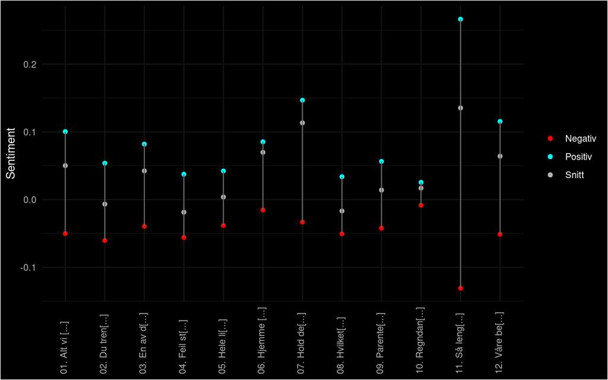

```r
no4_sent %>%
  mutate(neg_sent = neg_sent * -1) %>%
  ggplot(., aes(x = str_c(sprintf("%02d", 1:12),
                          ". ",
                          str_sub(titler, 1, 7),
                          "[...]"))) +
  geom_point(aes(y = neg_sent, color = "Negativ")) +
  geom_point(aes(y = pos_sent, color = "Positiv")) +
  geom_point(aes(y = sent, color = "Snitt")) +
  geom_linerange(aes(ymin = neg_sent, ymax = pos_sent), color = "gray40") +
  scale_color_manual(values = c("red", "cyan", "gray70")) +
  labs(x = NULL, y = "Sentiment", color = NULL) +
  ggdark::dark_theme_minimal() +
  theme(axis.text.x = element_text(angle = 90, vjust = .25, hjust = 0))
```

# 11 Temamodellering

# 12 Latente posisjoner

# 13 Noen tanker om videre læring

# 14 Oppsummering

# Referanser

Barnes, Jeremy, Samia Touileb, Lilja Øvrelid, and Erik Velldal. 2019. “Lexicon Information in Neural Sentiment Analysis: A Multi-Task Learning Approach.” In *Proceedings of the 22nd Nordic Conference on Computational Linguistics*, Turku, Finland: Linköping University Electronic Press, 175–86. https://aclanthology.org/W19-6119.

Benoit, Kenneth, and Akitaka Matsuo. 2020. *Spacyr: Wrapper to the ’spaCy’ ’NLP’ Library*. https://CRAN.R-project.org/package=spacyr.

Blei, David M. 2012. “Probabilistic Topic Models.” *Communications of the ACM* 55(4): 77–84.

Cooksey, Brian. 2014. “An Introduction to APIs.” *Zapier, Inc.* https://cdn.zapier.com/storage/learn_ebooks/e06a35cfcf092ec6dd22670383d9fd12.pdf.

D’Orazio, Vito, Steven T. Landis, Glenn Palmer, and Philip Schrodt. 2014. “[Separating the Wheat from the Chaff: Applications of Automated Document Classification Using Support Vector Machines](https://doi.org/10.1093/pan/mpt030).” *Political Analysis* 22(2): 224–42.

Denny, Matthew J., and Arthur Spirling. 2018. “Text Preprocessing For Unsupervised Learning: Why It Matters, When It Misleads, And What To Do About It.” *Political Analysis* 26(2): 168–89. https://doi.org/10.1017/pan.2017.44.

Feldman, Ronen, and James Sanger. 2006a. “[Categorization](https://doi.org/10.1017/CBO9780511546914.005).” In *The Text Mining Handbook: Advanced Approaches in Analyzing Unstructured Data*, Cambridge University Press, 64–81.

———. 2006b. “[Clustering](https://doi.org/10.1017/CBO9780511546914.006).” In *The Text Mining Handbook: Advanced Approaches in Analyzing Unstructured Data*, Cambridge University Press, 82–93.

Finseraas, Henning, Bjørn Høyland, and Martin G. Søyland. 2021. “Climate Politics in Hard Times: How Local Economic Shocks Influence MPs Attention to Climate Change.” *European Journal of Political Research* 60(3): 738–47. https://ejpr.onlinelibrary.wiley.com/doi/abs/10.1111/1475-6765.12415.

Grimmer, Justin, Margaret E. Roberts, and Brandon M. Stewart. 2022. *Text as Data: A New Framework for Machine Learning and the Social Sciences*. Princeton University Press.

Høyland, Bjørn, and Martin Søyland. 2019. “[Electoral Reform and Parliamentary Debates](https://doi.org/10.1111/lsq.12237).” *Legislative Studies Quarterly* 44(4): 593–615.

Hu, Minqing, and Bing Liu. 2004. “Mining and Summarizing Customer Reviews.” In *Proceedings of the Tenth ACM SIGKDD International Conference on Knowledge Discovery and Data Mining*, KDD ’04, New York, NY, USA: Association for Computing Machinery, 168–77. https://doi.org/10.1145/1014052.1014073.

Jørgensen, Fredrik et al. 2019. “NorNE: Annotating Named Entities for Norwegian.” https://arxiv.org/abs/1911.12146.

Lauderdale, Benjamin E., and Alexander Herzog. 2016. “[Measuring Political Positions from Legislative Speech](https://doi.org/10.1093/pan/mpw017).” *Political Analysis* 24(3): 374–94.

Laver, Michael, Kenneth Benoit, and John Garry. 2003. “Extracting Policy Positions from Political Texts Using Words as Data.” *American Political Science Review* 97(02): 311–31.

Liu, Bing. 2015. “Introduction.” In *Sentiment Analysis: Mining Opinions, Sentiments, and Emotions*, Cambridge University Press, 1–15. https://www.cambridge.org/core/books/sentiment-analysis/3F0F24BE12E66764ACE8F179BCDA42E9.

Lowe, Will. 2017. “[Understanding Wordscores](https://doi.org/10.1093/pan/mpn004).” *Political Analysis* 16(4): 356–71.

Lucas, Christopher et al. 2015. “[Computer-Assisted Text Analysis for Comparative Politics](https://doi.org/10.1093/pan/mpu019).” *Political Analysis* 23(2): 254–77.

Muchlinski, David, David Siroky, Jingrui He, and Matthew Kocher. 2016. “[Comparing Random Forest with Logistic Regression for Predicting Class-Imbalanced Civil War Onset Data](https://doi.org/10.1093/pan/mpv024).” *Political Analysis* 24(1): 87–103.

Pang, Bo, Lillian Lee, et al. 2008. “Opinion Mining and Sentiment Analysis.” *Foundations and Trends in information retrieval* 2(1–2): 1–135. https://www.cs.cornell.edu/home/llee/omsa/omsa.pdf.

Peterson, Andrew, and Arthur Spirling. 2018. “Classification Accuracy as a Substantive Quantity of Interest: Measuring Polarization in Westminster Systems.” *Political Analysis* 26(1).

Rinker, Tyler W. 2021. *textreadr: Read Text Documents into r*. Buffalo, New York. https://github.com/trinker/textreadr.

Roberts, Margaret E. et al. 2014. “Structural Topic Models for Open-Ended Survey Responses.” *American Journal of Political Science* 58(4): 1064–82.

Silge, Julia, and David Robinson. 2017. *Text Mining with R: A Tidy Approach*. O’Reilly Media, Inc. https://www.tidytextmining.com/.

Slapin, Jonathan B., and Sven-Oliver Proksch. 2008. “A Scaling Model for Estimating Time-Series Party Positions from Texts.” *American Journal of Political Science* 52(3): 705–22.

Søyland, Martin. 2022. *Stortingscrape: Scrape and Structure Raw Data from the Norwegian Parliament’s API*. https://github.com/martigso/stortingscrape.

Stortinget. 2022. *Stortingets Datatjeneste*. https://data.stortinget.no.

Wickham, Hadley. 2020. *Httr: Tools for Working with URLs and HTTP*. https://cran.r-project.org/web/packages/httr/vignettes/quickstart.html.

Wilkerson, John, and Andreu Casas. 2017. “Large-Scale Computerized Text Analysis in Political Science: Opportunities and Challenges.” *Annual Review of Political Science* 20(1): 529–44. https://doi.org/10.1146/annurev-polisci-052615-025542.

[^1]: Vi bruker `readr` fordi den virker godt sammen med `tidyverse` og er noe raskere enn base-funksjonen `read.csv()`
[^2]: se: https://github.com/ltgoslo/norsentlex